# Competencia de Métodos Avanzados de Estadística -Distribución Binaria

Andrés Franco, Julián Castelblanco y Edgar Alirio Rodridriguez

12/Oct/2019

# Introducción

A partir de la base de datos suministrada, que tiene las siguientes variables:

- yl: Variable binaria dependiente
- xl a X32: Variables independientes

Se procederá a construir uno modelo de prediccción, que responda a los requierimientos propuestos en la competencia, que tiene tres criterios de evaluación:

- Capacidad predictiva específica : 15%
- Capacidad predictiva general : 25%
- Selección de regresores : 25%

Teniendo en cuenta que para determinar la capacidad predictiva general será la: Presición-*Accuracy*=$\frac{Verdaderos positivos-TP + verdaderos Negativos-TN}{Tamaño de la muestra (n)}$ .

# 1. Carga de Datos y Análisis Descriptivo

```r
dtOriginal <-read.csv("databinarystudents.csv", header = TRUE, sep="," , na.strings = c("", "NA"), encoding = "UTF-8", stringsAsFactors=FALSE)
dtOriginal <- dtOriginal %>% na.omit()
#dtOriginal$yL <-as.factor(dtOriginal$yL)
#summary(dtOriginal)
dtDatBinaria <- dtOriginal[2:34]

## Transformación de variables
dtDatBinaria$yL <- as.factor(dtDatBinaria$yL)
dtDatBinaria$x3 <- as.factor(dtDatBinaria$x3)
dtDatBinaria$x4 <- as.factor(dtDatBinaria$x4)
dtDatBinaria$x5 <- as.factor(dtDatBinaria$x5)
dtDatBinaria$x6 <- as.factor(dtDatBinaria$x6)
dtDatBinaria$x7 <- as.factor(dtDatBinaria$x7)
dtDatBinaria$x13 <- as.factor(dtDatBinaria$x13)
dtDatBinaria$x14 <- as.factor(dtDatBinaria$x14)
dtDatBinaria$x15 <- as.factor(dtDatBinaria$x15)
dtDatBinaria$x16 <- as.factor(dtDatBinaria$x16)
dtDatBinaria$x17 <- as.factor(dtDatBinaria$x17)
dtDatBinaria$x18 <- as.factor(dtDatBinaria$x18)
dtDatBinaria$x19 <- as.factor(dtDatBinaria$x19)
dtDatBinaria$x20 <- as.factor(dtDatBinaria$x20)
dtDatBinaria$x28 <- as.factor(dtDatBinaria$x28)
dtDatBinaria$x29 <- as.factor(dtDatBinaria$x29)
#str(dtDatBinaria)
summary(dtDatBinaria)
```

```
##  yL            x1              x2         x3      x4      x5      x6
##  0: 50   Min.   :34.22   Min.   :  4.60   0:105   0:128   0:144   0:132
##  1:100   1st Qu.:56.87   1st Qu.: 14.72   1: 45   1: 22   1:  6   1: 18
##          Median :67.75   Median : 40.00
##          Mean   :64.32   Mean   : 50.37
##          3rd Qu.:71.52   3rd Qu.: 81.40
##          Max.   :78.84   Max.   :173.70
##  x7            x8              x9             x10
##  0:135   Min.   :10.62   Min.   : 0.00   Min.   :   1.406
##  1: 15   1st Qu.:14.51   1st Qu.:25.50   1st Qu.:  17.241
##          Median :15.46   Median :31.00   Median :  53.867
##          Mean   :15.40   Mean   :27.59   Mean   : 139.557
##          3rd Qu.:16.59   3rd Qu.:39.75   3rd Qu.: 123.527
##          Max.   :20.85   Max.   :45.00   Max.   :4547.958
##       x11              x12          x13     x14     x15     x16
##  Min.   : 4.948   Min.   : 0.0000   0:115   0:120   0:119   0:120
##  1st Qu.: 6.581   1st Qu.: 0.2606   1: 35   1: 30   1: 31   1: 30
##  Median : 7.749   Median : 2.7141
##  Mean   : 7.804   Mean   : 7.7746
##  3rd Qu.: 8.986   3rd Qu.:10.3450
##  Max.   :10.807   Max.   :47.4765
##  x17     x18     x19     x20          x21              x22
##  0:103   0:135   0:134   0:144   Min.   :0.0004   Min.   :0.000000
##  1: 47   1: 15   1: 16   1:  6   1st Qu.:0.1095   1st Qu.:0.000000
##                                  Median :0.7138   Median :0.000050
##                                  Mean   :0.5580   Mean   :0.006207
##                                  3rd Qu.:0.9144   3rd Qu.:0.000500
##                                  Max.   :0.9897   Max.   :0.790100
##       x23                x24               x25            x26
##  Min.   :0.000000   Min.   :0.00000   Min.   :4.00   Min.   :3.000
##  1st Qu.:0.001625   1st Qu.:0.00000   1st Qu.:6.00   1st Qu.:5.000
##  Median :0.021850   Median :0.00010   Median :6.00   Median :6.000
##  Mean   :0.239536   Mean   :0.03257   Mean   :6.38   Mean   :5.587
##  3rd Qu.:0.415925   3rd Qu.:0.00150   3rd Qu.:7.00   3rd Qu.:6.000
##  Max.   :0.994200   Max.   :0.84660   Max.   :9.00   Max.   :7.000
##       x27         x28     x29          x30             x31
##  Min.   : 11.09   0:130   0:142   Min.   :1.000   Min.   :0.01154
##  1st Qu.: 44.94   1: 20   1:  8   1st Qu.:2.000   1st Qu.:0.10043
##  Median : 66.40                   Median :4.000   Median :0.24764
##  Mean   : 78.49                   Mean   :3.927   Mean   :0.28314
##  3rd Qu.:102.72                   3rd Qu.:6.000   3rd Qu.:0.43699
##  Max.   :344.83                   Max.   :7.000   Max.   :0.66233
##       x32
##  Min.   :0.02304
##  1st Qu.:0.19443
##  Median :0.46109
##  Mean   :0.49105
##  3rd Qu.:0.79795
##  Max.   :0.99633
```

Al subir los datos se eliminan los registros sin datos y la variable con el identificador de cada registro. En una inspección visual de los datos se identifican varias variables que son del tipo categóricas, sin embargo, por el momento no se va a realizar ninguna operación u transformación sobre las variables, para mantener la condición inicial y realizar una análisis preliminar de los datos.

### 1.1 Frequencias Variables Categóricas

A continuación se presentan las tablas de frecuencias de las variables categóricas, en las que se puede apreciar que los datos están desbalanceados, por ejemplo las variables: x5, x6,x7,x14,x15,x16, x18, x19, x20, x28 y x29 tiene pocas observaciones con valor de 1, porque la mayoría de las observaciones tiene valor de 0.

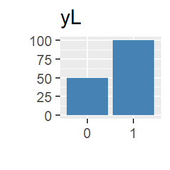

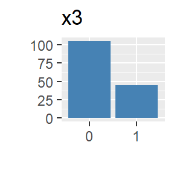

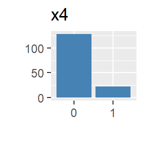

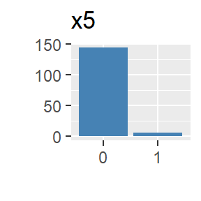

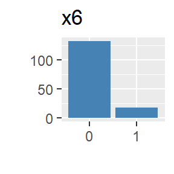

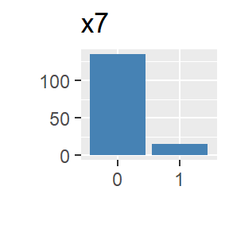

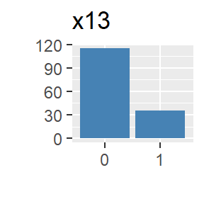

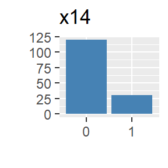

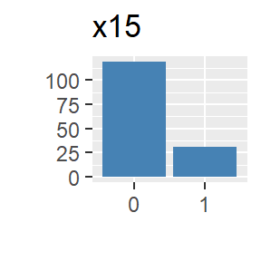

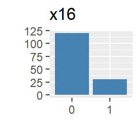

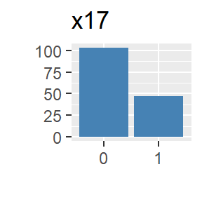

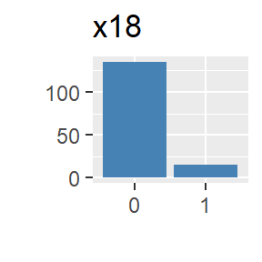

[7 more figures not shown]

### 1.2 Distibucion variables continuas

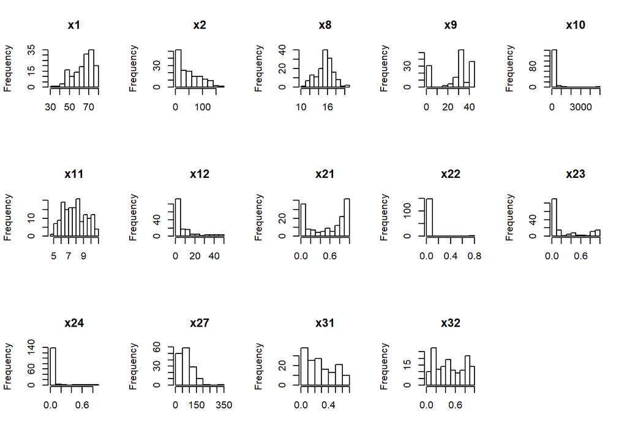

### 1.3 Identificación de Valores Atípicos Analizando los valores mínimos, máximos y la media de cada variable se identifica que en algunas variables existen una diferencia sustancial entre los valores extremos y el quartil más cercano, por lo que se procederá a visualizar la distribución de los datos para estas variables.

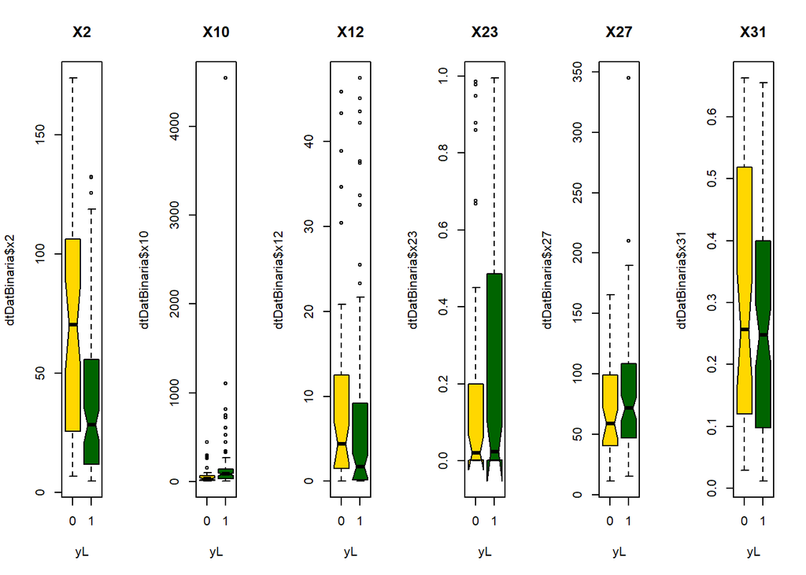

Claramente se identifica que en el caso de la variable x10, en la que no se alcanza a percibir la forma del bloxplot, cuya media es de 139.557 y se identifica que existe un outlier que supera el valor de 4000. Algo similar ocurre con la variable x27, por lo que se identificará cuáles son estos outliers y a qué observaciones corresponden.

```r
outlierX10<-outliers::outlier(dtDatBinaria$x10)
outlierX27<-outliers::outlier(dtDatBinaria$x27)
dtDatBinaria[dtDatBinaria$x10==outlierX10 | dtDatBinaria$x27==outlierX27,c("x10","x27")]
```

```
##          x10    x27
## 138 4547.958 344.83
```

Coincidencialmente se identifica que los outliers de las variables x10 y x27 corresponden a la observación 138. Sin embargo, antes de tomar una decisión sobre eliminar o no está observación se procederá a realizar otras validaciones.

# 2. Validación de Supuestos de una Regresión Logística

La Regresión Logística 1 no sigue los mismos supuestos de una Regresión Lineal, por lo que no se requiere:

- Validar que exista una relación líneal entre las variables independientes y la independiente, porque la Logística puede manejar todo tipo de relaciones, La regresión logística puede manejar todo tipo de relaciones, porque aplica una transformación logarítmica no lineal a la razón de probabilidades pronosticada.
- Los residuales no deben tener una distribución normalmente distribuida.
- Homoscedastadicida no es necesaria.
- Las variables independientes no requieren ser una métrica (intervalo o radio).

Sin embargo, para mejorar los resultados predicción en el del modelo de regresión que se identificar, se debe de validar los siguientes supuestos.

- Identificar si existen valores extremos o influenciadores.
- Verificar si existe multicolinealidad.

### 2.1 Valores Influyentes  
Se considera conveniente identificar si existen valores extremos que tengan una influencia significativa en el cálculo de los valores de la regresión 2, para lo que se utilizará la métrica denominada Distancia de *Cook*, que se calcula removiendo del modelo el i-ésimo dato y calculando la regresión, sumando el cambio de todos los valores del modelo de regresión dado que se se removió el el i-ésimo dato. La formula de la distancia de Cook es: $D_i=\frac{\sum_{j=1}^n(\hat{Y}_j - \hat{Y}_{j(i)})^2}{(p+1)\hat{σ}^2}$

Teniendo como referencia del punto de corte la formula $\frac{4}{n-p-1}$, siendo *n* el número de observaciones, *p* el número de variables predictoras.

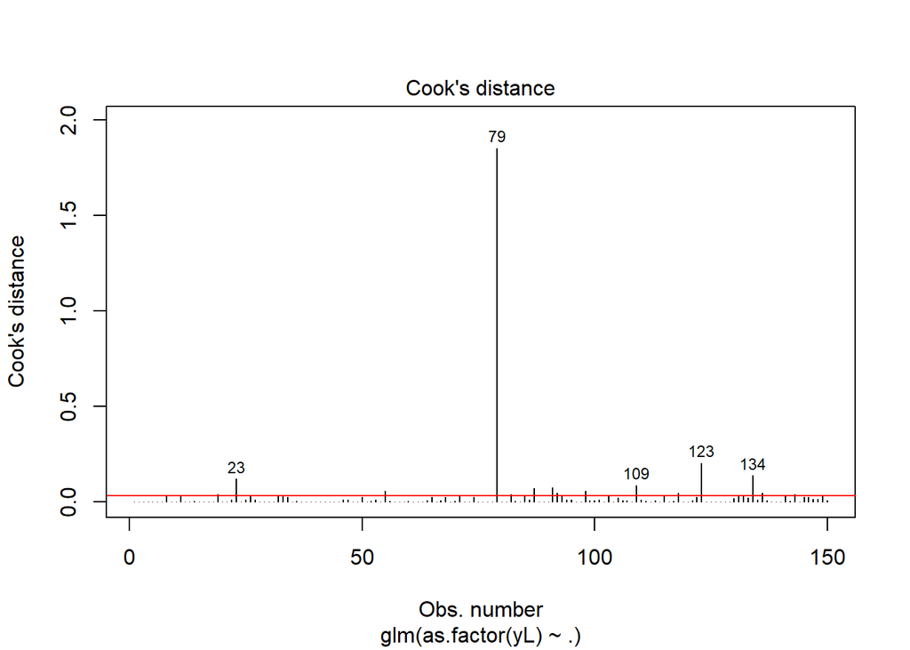

```r
# Verificando valores extremos según la distancia de Cook
modelLogistic <- glm(as.factor(yL)~., data=dtDatBinaria, family="binomial")
dfcookDistance <- as.data.frame(cooks.distance(modelLogistic))
names(dfcookDistance)<-"cooksd"
numObservaciones <-nrow(dtDatBinaria)
numPredictoras <- ncol(dtDatBinaria)-1
#par(mfrow=c(2,1))
plot(modelLogistic, which = 4, id.n = 5)
#plot(cooks.distance(modelLogistic), pch=23,bg='orange',cex=2, ylab="Cook's Distance")
abline(h=4/(numObservaciones-numPredictoras-1), col="red")
```

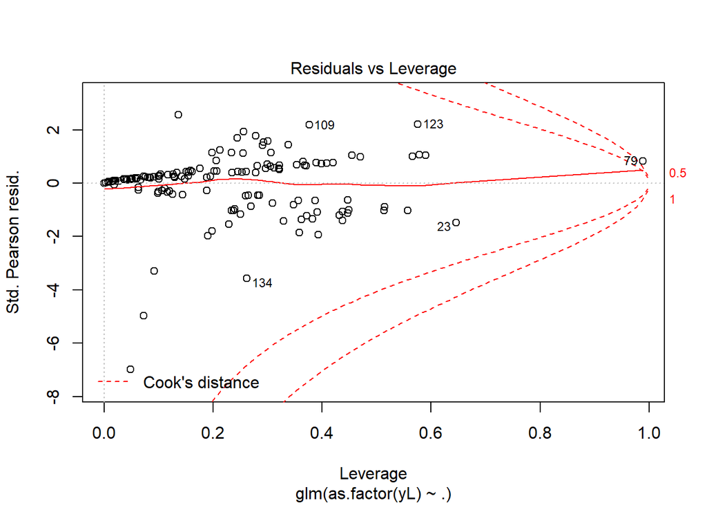

```r
plot(modelLogistic, which = 5, id.n = 5)
```

```r
#outlierTest(modelLogistic)
#influencePlot(modelLogistic)
```

Al analizar la gráfica inferior se identifica que el registro 79 tiene una distancia de *Cook* de 1.85 que considerablemente supera el valor de la línea roja o punto de corte que es de0.03.

En la segunda gráfica en la que se presentan los *Residuals vs Leverage*, claramente se identifica que la observación 79 está superando (a la derecha) la línea roja discontinua que delimita la distancia de *Cook*,lo que indica que corresponde a un valor extremo que tiene una inflencia significativa en el resultado del cálculo de la regresión, ratificando lo que se evidenció en la primera gráfica.

Al revisar el resultado de la distancia de *Cook* de la observación 138, no se detecta que esté dentro de los puntos identifica como posibles influenciadores (79, 123, 23, 134 y 109). Por lo que no se considera conveniente eliminarlo del conjunto de datos para constriuir el modelo de la regresión.

De acuerdo con esto la recomendación es eliminar del conjunto de datos la observación 79 y a verificar como queda la distribución de la distancia de Cook de las restantes observaciones.

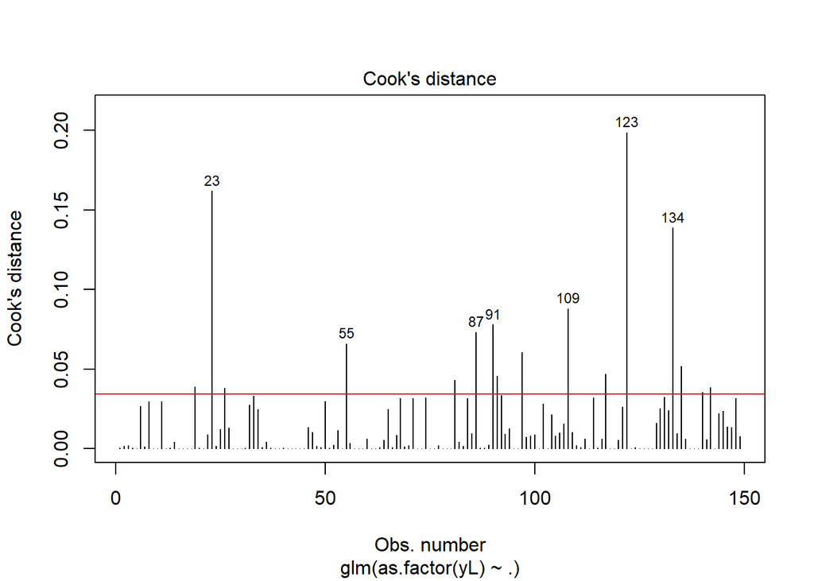

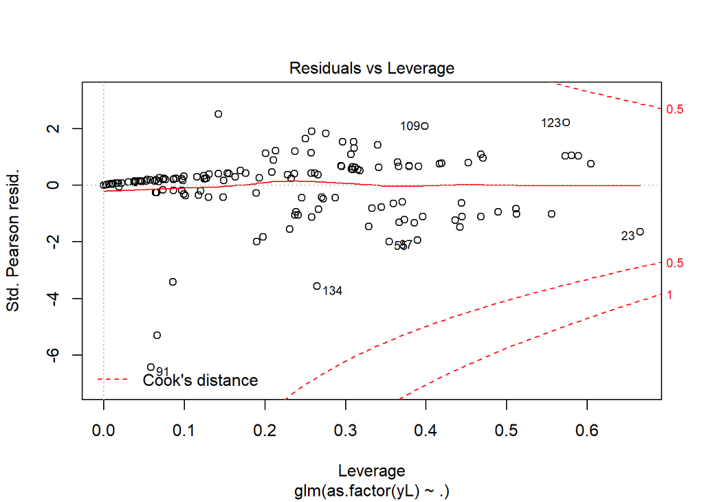

Después de eliminar el registro 79, en la primera gráfica indicaría que las siguientes observaciones 123, 23, 134,109, 91, 87, 55, entre otros, pero al revisar la segunda gráfica se establece que están dentro del área que define la línea roja discontinua que demarca la distancia de *Cook*, por lo que no son influyentes en el cálculo de la regresión.  
### 2.2 Verficando Multicolinealidad A continuación se procederá a verificar si existe colinealidad entre dos o más variables predictoras, para lo que se calculará el Factor de Inflación de Varianza (VIF)2, que identifica cómo la varianza de los coeficientes de la regresión son inflados debido a multicolinealidad del modelo. $VIF=\frac{1}{Tol}=\frac{1}{1-R^2}$

El menor valor de VIF es uno (1) que indica ausencia de multicolinealidad. La recomendación es que los valores de VIF que sean mayores de 5 o 10 es un indicio de multicolinealidad, algunas fuentes mencionan que para modelos débiles, a partir de un VIF de 2.5 puede ser un indicio de multicolinealidad y otras afirman que un valor de VIF inferior a 4 se consdiera bueno para el modelo, por lo que se establecerá como valor de referencia de multicolinealidad un valor de 5.

```
## c("x1", "x2", "x11", "x21", "x23", "x31", "x32", "x16", "x17",
## "x18")
```

|  | VIF | collinearity |
| --- | --- | --- |
| x1 | 14.82 | True |
| x2 | 12.34 | True |
| x11 | 5.42 | True |
| x21 | 12.86 | True |
| x23 | 9.50 | True |
| x31 | 30.59 | True |
| x32 | 29.73 | True |
| x16 | 7.12 | True |
| x17 | 11.67 | True |
| x18 | 6.38 | True |

Después de realizar el cálculo del VIF se identifica que las siguientes variables x1, x2, x11, x21, x23, x31, x32, x16, x17, x18 tienen un valor de VIF superior a 5, por lo que se procederá a calcular ¿Cuál es la correlación entre estas variables? dejando solamente las que tengan un valor superior a 0.3.

|  | x1 | x2 | x11 | x21 | x23 | x31 | x32 |
| --- | --- | --- | --- | --- | --- | --- | --- |
| x1 |  | 0.941 | 0.834 | 0.305 |  |  |  |
| x2 | 0.941 |  | 0.824 | 0.369 | 0.326 |  |  |
| x11 | 0.834 | 0.824 |  | 0.346 |  |  |  |
| x21 | 0.305 | 0.369 | 0.346 |  | 0.768 | 0.328 |  |
| x23 |  | 0.326 |  | 0.768 |  |  |  |
| x31 |  |  |  | 0.328 |  |  | 0.973 |
| x32 |  |  |  |  |  | 0.973 |  |

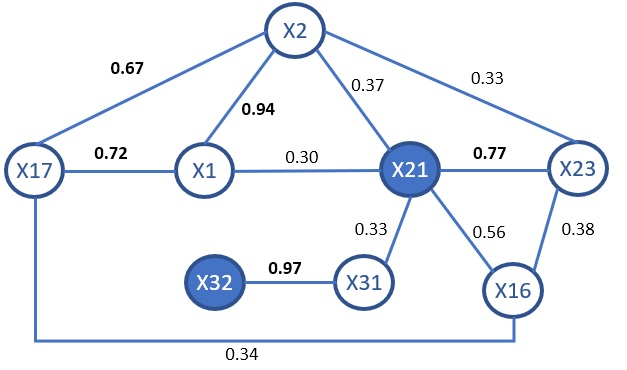

Luego se dejan las variables x17, x21 y x32, y se procede a eliminar x1, x2, x16, x23 y x31. Dado que no se identificó ninguna correlación de x18, x18 y x20, éstas de dejarían dentro del conjunto de datos.

Luego nuevamente se procede a calcular el VIF para comprobar que no exista multicolinealidad.

|  | VIF | collinearity |
| --- | --- | --- |
| x8 | 3.655323 | False |
| x10 | 1.759160 | False |
| x11 | 2.963108 | False |
| x12 | 1.886635 | False |
| x21 | 2.723590 | False |
| x22 | 1.350577 | False |
| x24 | 1.979554 | False |
| x27 | 2.798543 | False |
| x32 | 1.496898 | False |
| x3 | 4.033607 | False |
| x4 | 2.549824 | False |
| x5 | 1.543750 | False |
| x6 | 2.720090 | False |
| x7 | 1.679616 | False |
| x13 | 3.776492 | False |
| x14 | 1.667787 | False |
| x15 | 2.557794 | False |
| x17 | 5.467642 | True |
| x18 | 4.107774 | False |
| x19 | 2.661488 | False |
| x20 | 2.901315 | False |
| x28 | 1.467172 | False |
| x29 | 1.661010 | False |
| x9 | 1.619524 | False |
| x25 | 2.410213 | False |
| x26 | 3.473410 | False |
| x30 | 2.806980 | False |

# 3. Identificación de Modelos que Mejoren la Predicción

Luego de esta división de las observaciones se tiene que el subconjunto de entrenamiento tiene 105 observaciones y el subconjunto con los datos de prueba tiene 44 observaciones.

### 3.1 Métodos Frecuentistas

#### 3.1.1 Regresion Logística utilizando el Método Stepwise

```
## [1] 0.6818182
```

```
## Balanced Accuracy
##         0.6137931
```

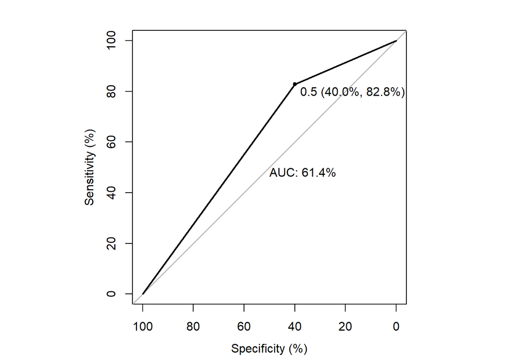

#### 3.1.2 Regresion lineal utilizando el Método Ridge

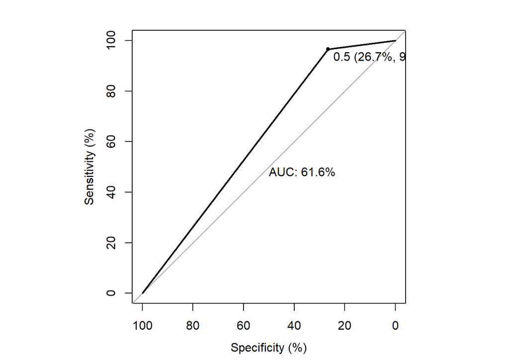

#### 3.1.3 Regresion lineal utilizando el Método Lasso La Regresión Lasso es una metodologia, para seleccion de variables y resolver problemas de regularizacion. En este ejercicio sera utilizada para minimizar la cantidad de parametros de una regresión, que permitan explicar mejor el modelo.
$$\begin{equation}
\beta^* = \min\limits_{\beta \in \mathbb{R}^p} \sum_{i=1}^n \left[y_i- x_i^{'}\beta_i \right]^2 + \lambda \sum_{j=1}^p \mid \beta_j \mid
\end{equation}$$
donde $\lambda$ es el parametro de penalización, esta funcion no solo minimiza la funcion de los residuos al cuadrado, si no tambien la estimación de los parametros reduciendolos a 0. La diferencia entre Lasso y Ridge es la funcion de penalización de los parametros.4

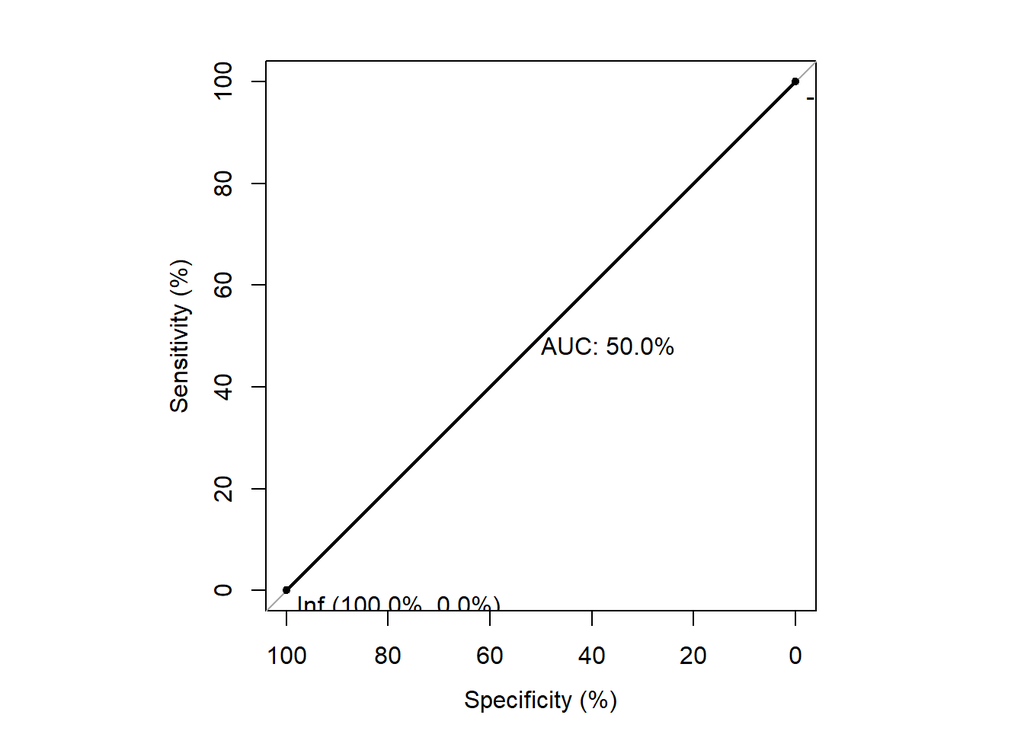

#### 3.1.4 Regresion lineal utilizando el Método Elastic Net

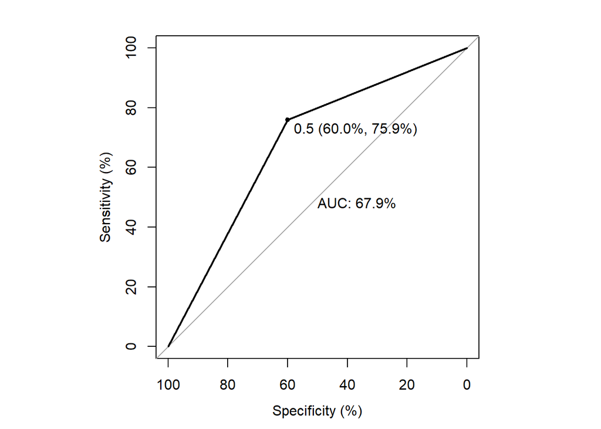

### 3.2 Enfoques Bayesianos

#### 3.2.1 Promedio del Modelo Bayesiano

Utilizando Bayesian Model Averaging (BMA) es una metodología bayesiana que utiliza una búsqueda estocástica que compara diferentes modelos por su probabilidad aposteriori4, donde propusieron un enfoque de Markov Chain Monte Carlo que se aproxima directamente a la solución exacta, lo que lleva aproxima la respuesta sin tener que calcular $2^p$ modelos diferentes, ya que los procedimientos comunes generalmente requieren mucho tiempo de cómputo para hacer una búsqueda exhaustiva.

Sea $M= \{M_1,M_2, \dotsc,M_{2^k}\}$ el conjunto de todos los modelos posibles, donde cada uno de ellos depende de un conjunto de parámetros $\alpha_j$ $\forall j \in 1,\dotsc,2^k$, $k$ es el número de regresores posibles y $y$ es la variable dependiente, la probabilidad de modelo posterior se define como:
$$\begin{equation}
P(M_j \mid y, M)=\frac{P(y \mid M_j)\pi(M_j)}{\sum_{i=1}^{m}P(y \mid M_i)\pi(M_i)} \hspace{5mm} \forall j=1,2,\dotsc,m
\end{equation}$$

donde,
$$\begin{equation}
P(y \mid M_j)=\int ...\int P(y\mid \alpha_j, \hspace{2mm} M_j)\pi(\alpha_j \mid M_j ) d \alpha_j \hspace{5mm} \forall j=1,2,\dotsc,m
\end{equation}$$

La probabilidad integrada del modelo $M_j$, $\alpha_j$ es el vector de parámetros del modelo $M_j$, $\pi(\alpha_j \mid M_j )$ es la prior de los parámetros bajo $M_j$, $P(y\mid\alpha_j,M_j)$ es la probabilidad y $\pi(M_j)$ es la probabilidad previa del $M_j$ sea el mejor modelo.

#### Se selecciona el modelo $y~ x24+x17+x18$

```r
bma_binary_bicreg<-bic.glm(dtBinEntrenamiento[,-1], dtBinEntrenamiento[,1],maxCol = 33, nbest = 1000,
                           strict =TRUE,glm.family="binomial")
summary(bma_binary_bicreg)
```

```
##
## Call:
## bic.glm.data.frame(x = dtBinEntrenamiento[, -1], y = dtBinEntrenamiento[,     1], glm.family = "binomial", strict = TRUE, maxCol = 33,     nbest = 1000)
##
##
##   15  models were selected
##  Best  5  models (cumulative posterior probability =  0.6484 ):
##
##            p!=0   EV      SD        model 1    model 2    model 3
## Intercept  100    0.8500    1.5322     2.1276     1.3179     1.1472
## x1.x       15.4   0.6256    1.5794      .          .          .
## x2.x       11.5  -0.4067    1.2257      .          .          .
## x8.x        0.0   0.0000    0.0000      .          .          .
## x10.x       0.0   0.0000    0.0000      .          .          .
## x11.x       7.0   0.1783    0.7048      .          .          .
## x12.x       0.0   0.0000    0.0000      .          .          .
## x21.x       0.0   0.0000    0.0000      .          .          .
## x22.x       0.0   0.0000    0.0000      .          .          .
## x23.x      62.7   1.8782    1.7232      .         2.6499     2.7636
## x24.x      44.6  -2.2942    2.9836    -5.6752      .        -4.0550
## x27.x       0.0   0.0000    0.0000      .          .          .
## x31.x       0.0   0.0000    0.0000      .          .          .
## x32.x       0.0   0.0000    0.0000      .          .          .
## x3.x        0.0
##     .1            0.0000    0.0000      .          .          .
## x4.x       26.0
##     .1           -0.6105    1.1435      .          .          .
## x5.x        3.4
##     .1            0.5933  323.5371      .          .          .
## x6.x        0.0
##     .1            0.0000    0.0000      .          .          .
## x7.x        0.0
##     .1            0.0000    0.0000      .          .          .
## x13.x       0.0
##      .1           0.0000    0.0000      .          .          .
## x14.x       0.0
##      .1           0.0000    0.0000      .          .          .
## x15.x       0.0
##      .1           0.0000    0.0000      .          .          .
## x16.x       0.0
```

[output cut: 59 more lines]

```
##      .1        .          .
## x20.x
##      .1        .          .
## x28.x
##      .1        .          .
## x29.x
##      .1        .          .
## x9.x           .          .
## x25.x          .          .
## x26.x          .          .
## x30.x          .          .
##
## nVar            3          3
## BIC        -364.4699  -364.1434
## post prob     0.070      0.059
```

```r
nombres_bma<-names(dtBinEntrenamiento[,-1])
nombres_bma<-nombres_bma[bma_binary_bicreg$which[1,]]


model_bma_bin <- glm(yL ~ x24+x17+x18 , family="binomial", data=dtBinEntrenamiento)

predict_lm_bma <-model_bma_bin %>% predict(dtBinPrueba,type="response")
mse_lm_bma<-mean((dtBinPrueba$yL - predict_lm_bma)^2)

predict_Outcomes_BMA <- ifelse(predict_lm_bma < 0.6,0,1)
table_mat <- table(predict_Outcomes_BMA, dtBinPrueba$yL)
accuracy_Test_BMA <- sum(diag(table_mat)) / sum(table_mat)
```

##### Comportamiento de las variables con BMA

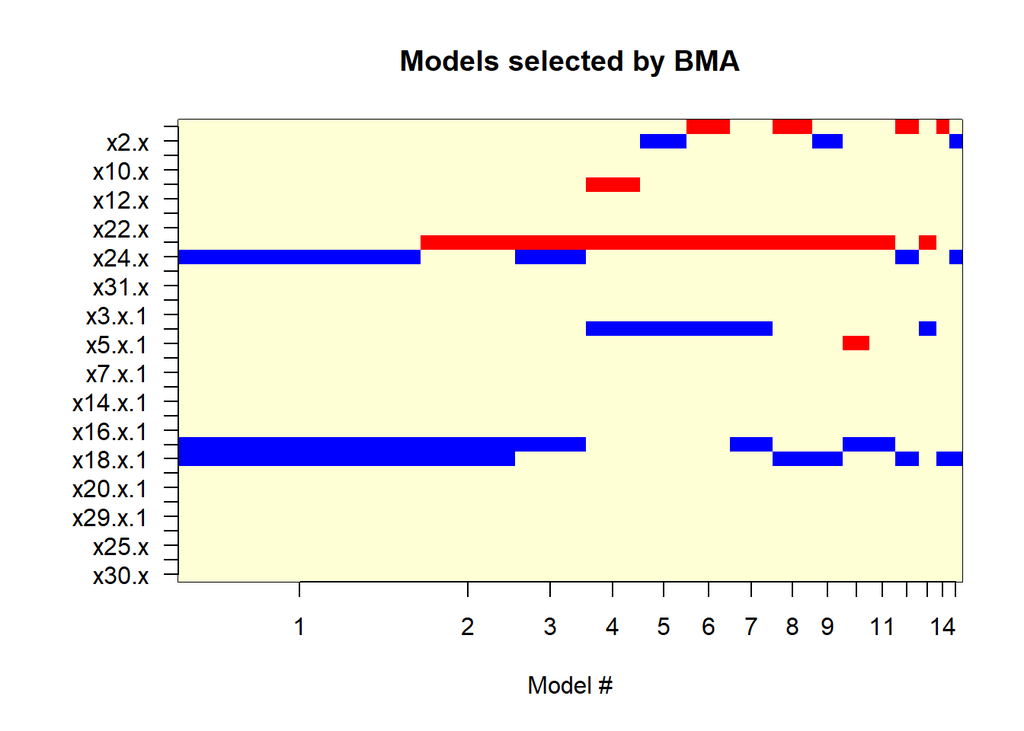

```r
imageplot.bma(bma_binary_bicreg)
```

# 4. Resumen de Resultados A continuación se presenta el resumen de los resultados obtenidos con los diferentes métodos.

[output not shown]

Guardar modelo seleccionado:

```r
# Guardar Base Modelo Seleccionado
save(model_bma_bin, file = "ModelBinary.RData")
```

# Bibliografía